# Mid_Term2_MN

```r
library(readxl)
library(tidyverse)
library(gt)
library(readr)

data_poll <- read_excel("~/Documents/School/Spring 2025/Math 250/Mid term 2/pizza_poll.xlsx")
data_ratings <- read_excel("~/Documents/School/Spring 2025/Math 250/Mid term 2/pizza_ratings.xlsx")
```

# Question 1

```r
data_poll <- data_poll %>%
  mutate(score = case_when(
    answer == "Excellent" ~ 5,
    answer == "Good" ~ 4,
    answer == "Average" ~ 3,
    answer == "Fair" ~ 2,
    answer == "Never Again" ~ 1,
    TRUE ~ NA_real_))

Q_1_Table <- data_poll %>%
  filter(!is.na(score)) %>%
  group_by(place) %>%
  summarize(
    tot_p = sum(score * votes, na.rm = TRUE),
    tot_resp = sum(votes, na.rm = TRUE),
    avg_rat = round(tot_p / tot_resp, 2)
  ) %>%
  filter(tot_resp >= 15) %>%
  arrange(desc(avg_rat)) %>%
  slice_head(n = 10) %>%
  gt()

Q_1_Table
```

| place | tot_p | tot_resp | avg_rat |
| --- | --- | --- | --- |
| Tappo | 87 | 20 | 4.35 |
| Williamsburg Pizza | 159 | 38 | 4.18 |
| Saluggi's | 134 | 33 | 4.06 |
| Rocky's | 113 | 28 | 4.04 |
| Fiore's | 479 | 119 | 4.03 |
| Little Italy Pizza | 131 | 33 | 3.97 |
| Rocco's Pizza Joint | 91 | 23 | 3.96 |
| New York Pizza Suprema | 74 | 19 | 3.89 |
| Stella's Pizza | 58 | 15 | 3.87 |
| Pizza Paradise | 65 | 17 | 3.82 |

# Question 2

## Graph

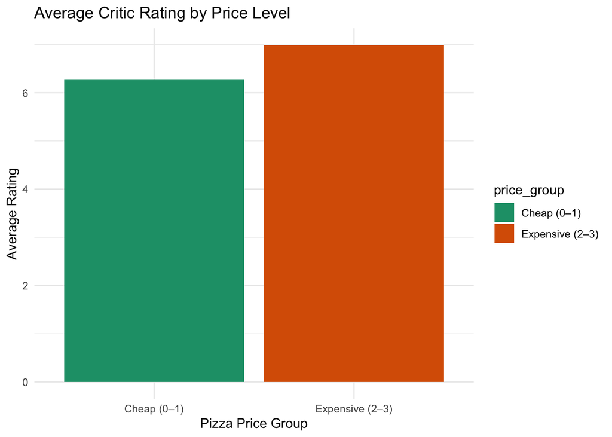

```r
Q2_Graph <- data_ratings %>%
mutate(price_group = case_when(
  price_level %in% c(0, 1) ~ "Cheap (0–1)",
  price_level %in% c(2, 3) ~ "Expensive (2–3)",
  TRUE ~ NA_character_
))
ggplot(Q2_Graph,
       aes(x = price_group,
          y = rating,
          fill = price_group)) +
  geom_bar(stat = "summary",
           fun = "mean") +
  labs(title = "Average Critic Rating by Price Level",
       x = "Pizza Price Group",
       y = "Average Rating") +
  theme_minimal() +
  scale_fill_brewer(palette = "Dark2")
```

## Test

```r
cheap <- data_ratings %>%
  filter(price_level %in%
           c(0, 1)) %>%
  pull(rating)
expensive <- data_ratings %>%
  filter(price_level %in% c(2, 3)) %>%
  pull(rating)

t.test(expensive, cheap, alternative = "greater")
```

```
    Welch Two Sample t-test

data:  expensive and cheap
t = 4.3183, df = 432.84, p-value = 9.755e-06
alternative hypothesis: true difference in means is greater than 0
95 percent confidence interval:
 0.4389531       Inf
sample estimates:
mean of x mean of y
 6.991171  6.281217
```

## Conclusion

The p-value is smaller than our significance level p = 9.755*10^-6 meaning that the null hypothesis is rejected and the alternative hypothesis is accepted. In other words, Higher pizza prices likely lead to higher average ratings for said pizza.

# Question 3

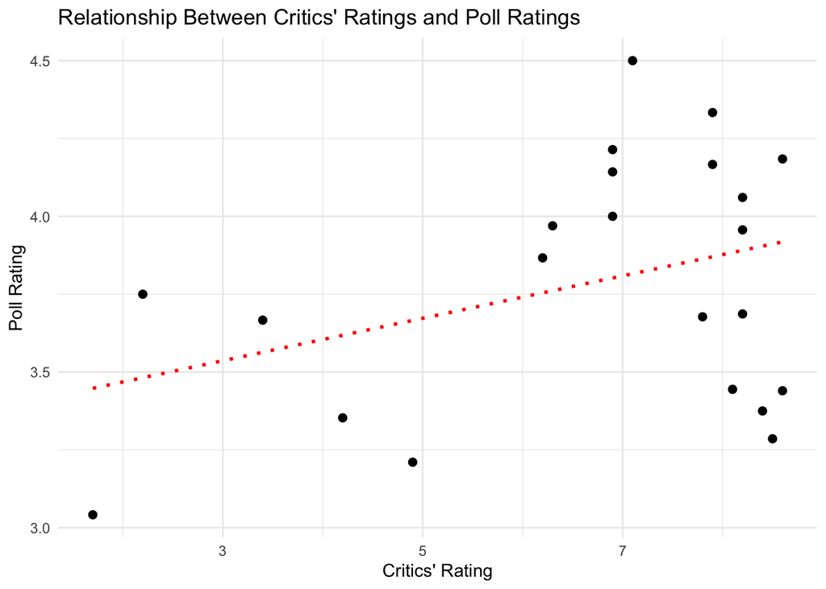

```r
poll_scores <- data_poll %>%
  filter(!is.na(score)) %>%
  group_by(place) %>%
  summarize(poll_rating = sum(score * votes, na.rm = TRUE) / sum(votes, na.rm = TRUE))

# Then join with critic ratings
merged_data <- data_ratings %>%
  inner_join(poll_scores, by = c("name" = "place")) %>%
  rename(critics_rating = rating)

# Plot
ggplot(merged_data, aes(x = critics_rating, y = poll_rating)) +
  geom_point(size = 2) +
  geom_smooth(method = "lm", se = FALSE, color = "red", linetype = "dotted") +
  labs(
    title = "Relationship Between Critics' Ratings and Poll Ratings",
    x = "Critics' Rating",
    y = "Poll Rating"
  ) +
  theme_minimal()
```

There appears to be a weak positive relationship between the 2 variables. In other words poll voters and pizza critics are in some agreement on pizza quality.

Lets confirm using a linear model

```r
lm_model <- lm(poll_rating ~ critics_rating, data = merged_data)
summary(lm_model)
```

```
Call:
lm(formula = poll_rating ~ critics_rating, data = merged_data)

Residuals:
    Min      1Q  Median      3Q     Max
-0.6254 -0.3708  0.1077  0.2677  0.6843

Coefficients:
               Estimate Std. Error t value Pr(>|t|)
(Intercept)     3.33179    0.27933  11.928 1.51e-10 ***
critics_rating  0.06816    0.03994   1.707    0.103
---
Signif. codes:  0 '***' 0.001 '**' 0.01 '*' 0.05 '.' 0.1 ' ' 1

Residual standard error: 0.3841 on 20 degrees of freedom
Multiple R-squared:  0.1271,    Adjusted R-squared:  0.08347
F-statistic: 2.912 on 1 and 20 DF,  p-value: 0.1034
```

# Question 4

```r
data_spot <- read_csv("~/Documents/School/Spring 2025/Math 250/Mid term 2/spotify_sample.csv")
```

## Hypotheses

Null: $H_0:$ The mean energy level is the same across all genres

Alternative: $H_a:$ At least one genre has a different mean energy level

## Graph

[figure not shown]

```r
ggplot(data_spot,
       aes(x = energy,
           y = genre,
           fill = genre)) +
  geom_boxplot() +
  theme_minimal() +
  scale_fill_brewer(palette = "Dark2") +
  labs(title = "Energy Levels Across Music Genres",
       x = "Genre",
       y = "Energy Level") +
  theme_minimal() +
  theme(legend.position = "none")
```

## Test

```r
anova_model <- aov(energy ~ genre,
                   data = data_spot)
summary(anova_model)
```

```
             Df Sum Sq Mean Sq F value   Pr(>F)
genre         5 0.6834 0.13668   5.902 6.88e-05 ***
Residuals   114 2.6399 0.02316
---
Signif. codes:  0 '***' 0.001 '**' 0.01 '*' 0.05 '.' 0.1 ' ' 1
```

Since the p-value is so small this supports that we reject the null hypothesis and and accept the alternative hypothesis, lets do a Tukey Post hoc test to see:

```r
TukeyHSD(anova_model)
```

```
  Tukey multiple comparisons of means
    95% family-wise confidence level

Fit: aov(formula = energy ~ genre, data = data_spot)

$genre
               diff         lwr          upr     p adj
latin-edm  -0.08755 -0.22704326  0.051943263 0.4575815
pop-edm    -0.14800 -0.28749326 -0.008506737 0.0307671
r&b-edm    -0.19680 -0.33629326 -0.057306737 0.0011160
rap-edm    -0.23085 -0.37034326 -0.091356737 0.0000710
rock-edm   -0.10705 -0.24654326  0.032443263 0.2347447
pop-latin  -0.06045 -0.19994326  0.079043263 0.8078790
r&b-latin  -0.10925 -0.24874326  0.030243263 0.2149017
rap-latin  -0.14330 -0.28279326 -0.003806737 0.0403880
rock-latin -0.01950 -0.15899326  0.119993263 0.9985621
r&b-pop    -0.04880 -0.18829326  0.090693263 0.9123766
rap-pop    -0.08285 -0.22234326  0.056643263 0.5204789
rock-pop    0.04095 -0.09854326  0.180443263 0.9570510
rap-r&b    -0.03405 -0.17354326  0.105443263 0.9806925
rock-r&b    0.08975 -0.04974326  0.229243263 0.4289375
rock-rap    0.12380 -0.01569326  0.263293263 0.1125716
```

## Conclusion

There is strong statistical evidence that the average energy level differs by genre as the p-value of p < 6.88*10^-5 suggests that we reject the null hypothesis and accept the alternative hypothesis. In other words, this suggests that genre and energy level are not independent.

# Question 5

## Hypotheses

Null: $H_0:$There is no correlation between energy and tempo

Alternative: $H_a:$ There is a correlation between energy and tempo

## Graph

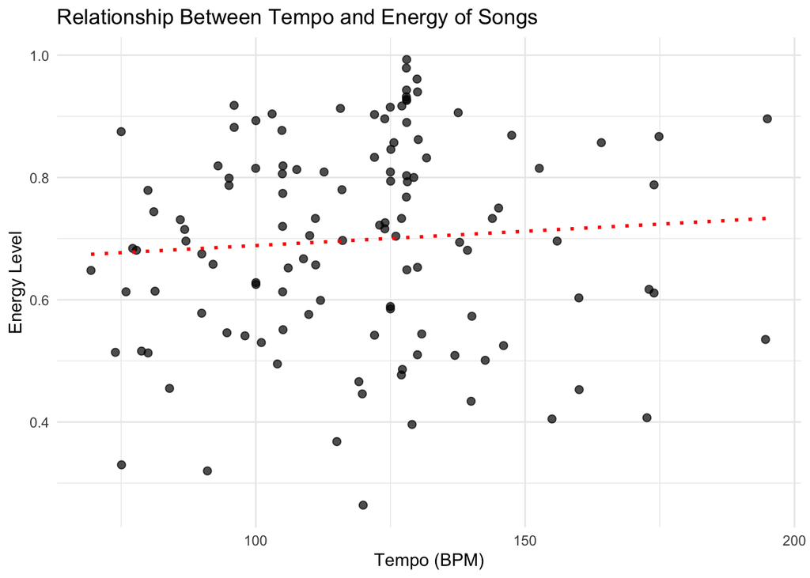

```r
ggplot(data_spot,
       aes(x = tempo,
           y = energy)) +
  geom_point(size = 2, alpha = 0.7) +
  geom_smooth(method = "lm",
              se = FALSE,
              color = "red",
              linetype = "dotted") +
  labs(title = "Relationship Between Tempo and Energy of Songs",
       x = "Tempo (BPM)",
       y = "Energy Level") +
  theme_minimal()
```

## Test

```r
lm_model <- lm(energy ~ tempo, data = data_spot)
summary(lm_model)
```

```
Call:
lm(formula = energy ~ tempo, data = data_spot)

Residuals:
     Min       1Q   Median       3Q      Max
-0.43401 -0.12158  0.01474  0.12976  0.29121

Coefficients:
             Estimate Std. Error t value Pr(>|t|)
(Intercept) 0.6419524  0.0714988   8.979 5.18e-15 ***
tempo       0.0004674  0.0005875   0.796    0.428
---
Signif. codes:  0 '***' 0.001 '**' 0.01 '*' 0.05 '.' 0.1 ' ' 1

Residual standard error: 0.1674 on 118 degrees of freedom
Multiple R-squared:  0.005336,  Adjusted R-squared:  -0.003093
F-statistic: 0.633 on 1 and 118 DF,  p-value: 0.4278
```

## Conclusion

The p-value is quite large(p = 0.4278) thus we fail to reject the null hypothesis. In other words, tempo and energy appear to be independent in this sample.

## Question 6

```r
data_scoob <- read_excel("~/Documents/School/Spring 2025/Math 250/Mid term 2/scooby.xlsx")

scooby_unmask <- data_scoob %>%
  pivot_longer(cols = starts_with("unmask_"),
               names_to = "unmasker",
               names_prefix = "unmask_",
               values_to = "did_unmask") %>%
  filter(did_unmask == TRUE) %>%
  select(title, imdb, unmasker)

glimpse(scooby_unmask)
```

```
Rows: 261
Columns: 3
$ title    <chr> "What a Night for a Knight", "A Clue for Scooby Doo", "Hassle…
$ imdb     <dbl> 8.1, 8.1, 8.0, 7.8, 7.5, 8.4, 7.6, 8.2, 8.4, 8.1, 8.4, 8.3, 7…
$ unmasker <chr> "scooby", "fred", "fred", "fred", "scooby", "fred", "shaggy",…
```

Viewing the table

```r
scooby_unmask %>%
  count(unmasker, sort = TRUE) %>%
  gt() %>%
  cols_label(unmasker = "Gang Member",
             n = "Unmask Count"
  ) %>%
  tab_header(title = "Who Unmasked the Villain the Most?")
```

Who Unmasked the Villain the Most?

| Gang Member | Unmask Count |
| --- | --- |
| fred | 90 |
| velma | 75 |
| other | 34 |
| daphnie | 30 |
| scooby | 21 |
| shaggy | 11 |

## Question 7

```r
top_motives <- data_scoob %>%
  count(motive,
        sort = TRUE) %>%
  slice_head(n = 3) %>%
  pull(motive)

top_terrains <- data_scoob %>%
  count(setting_terrain,
        sort = TRUE) %>%
  slice_head(n = 2) %>%
  pull(setting_terrain)

scooby_sm <- data_scoob %>%
  filter(format == "TV Series",
         motive %in% top_motives,
         setting_terrain %in% top_terrains) %>%
  select(title,motive, setting_terrain)

glimpse(scooby_sm)
```

```
Rows: 167
Columns: 3
$ title           <chr> "What a Night for a Knight", "Scooby-Doo and a Mummy, …
$ motive          <chr> "Theft", "Theft", "Competition", "Theft", "Theft", "Th…
$ setting_terrain <chr> "Urban", "Urban", "Rural", "Urban", "Rural", "Urban", …
```

# Question 8

## Hypotheses

Null: $H_0:$ There is no association between motive and setting terrain (they are independent).

Alternative: $H_a:$ There is an association between motive and setting terrain (they are dependent).

## Graph

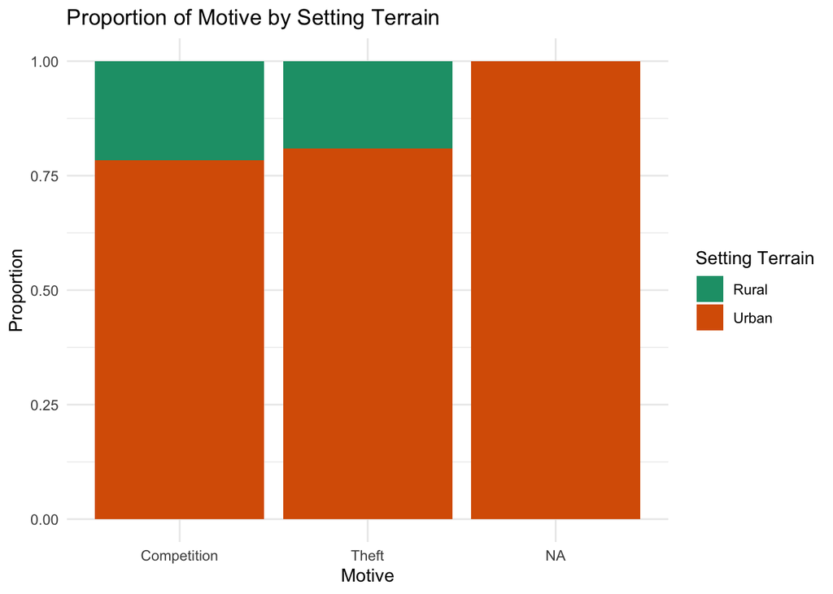

```r
ggplot(scooby_sm,
       aes(x = motive,
           fill = setting_terrain)) +
  geom_bar(position = "fill") +
  labs(title = "Proportion of Motive by Setting Terrain",
       x = "Motive",
       y = "Proportion",
       fill = "Setting Terrain") +
  scale_fill_brewer(palette = "Dark2") +
  theme_minimal()
```

## Test

```r
table_sm <- table(scooby_sm$motive, scooby_sm$setting_terrain)

chisq_test <- chisq.test(table_sm)

chisq_test
```

```
    Pearson's Chi-squared test with Yates' continuity correction

data:  table_sm
X-squared = 0.040102, df = 1, p-value = 0.8413
```

## Conclusion

The p-value = 0.8413 is much greater than the significance level, Therefore, we fail to reject the null hypothesis. In other words, the motive of the crime in the show and setting terrain appear to be independent in this case.